# Session1 Presentation

Sumeet Pal Singh  
04 April, 2020

### Aim of the course

- Foundation Course
- Independence in Data Analysis and Plotting
  - Independent: Use open-source software
  - Independent: Capable of performing the analysis being performed

### Goal of the course

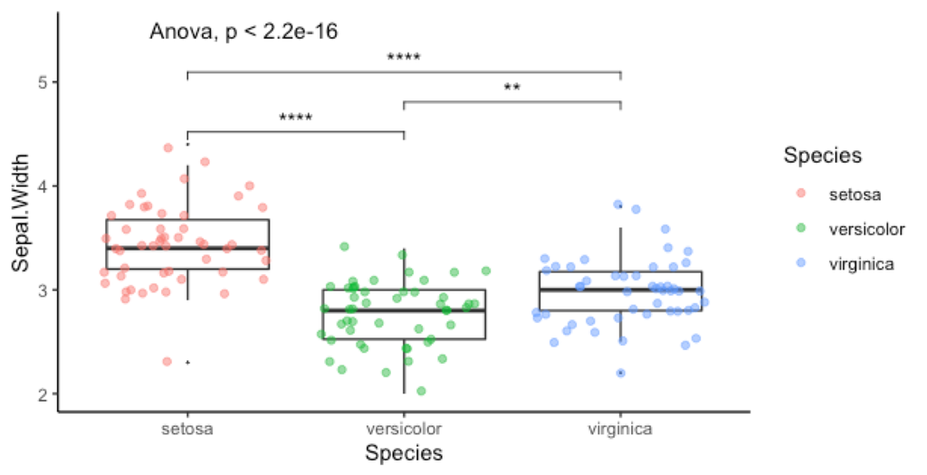

### What is not covered

- Bioinformatics
  - (Planning a follow-up course on bioinformatics)
- Algorithm: How to code new problem / new analysis
- Multiple methods for achieving same result.
  - We will show you one method to get you started. Further exploration depends on you!

### Timeline

- Two sessions per week
  - Each session ~ 1 – 2 hours
  - 5 – 6 sessions
- After each session, a practice homework will be assigned (This is the most important part of the course!!)
- Homework: 30 – 2 hours
- Per week: 3 – 5 hour commitment

### Session 1: Introduction to Rstudio

[figure not shown]

### Vectors

- Vector is a collection of scalars (E.g. 4 is a scalar; c(4, 3, 5) is a vector)
- Scalar are 0-dimensional. Vectors are 1-D.
- Four major types of vectors
1. Numerical: c(4, 3, 5)
2. Character: c(“A”, “B”, “C”) (Character scalar is called a “string”)
3. Factor (Grouping): factor(”Red”, “Red”, “Blue”, “Red”, “Blue”)
4. Logical: TRUE, FALSE, TRUE, TRUE, FALSE

### Function

- Used to perform a specific operation.
- Input (Arguments) -> function -> output
- output <- name(arguments)
- mode, length, log(), sqrt()

### Subsetting

- Select or extract values
- Use square brackets: [ ]
- Subsetting can be positional / condition (by name)

### Summary

- Vector is a collection of scalars
- Four major types of vectors
1. Numerical: c(4, 3, 5)
2. Character: c(“A”, “B”, “C”) (Character scalar is called a “string”)
3. Factor (Grouping): factor(”Red”, “Red”, “Blue”, “Red”, “Blue”)
4. Logical: TRUE, FALSE, TRUE, TRUE, FALSE
- To subset, use square brackets: [ ]

### Package

To install:

```r
install.package(“name”)
```

To use:

```r
library(package)
```

To learn more about:

```r
vignette(“package”)
```

[figure not shown]

### Last Slide

For more details on authoring R presentations please visit https://support.rstudio.com/hc/en-us/articles/200486468.